# Morphometric Analysis

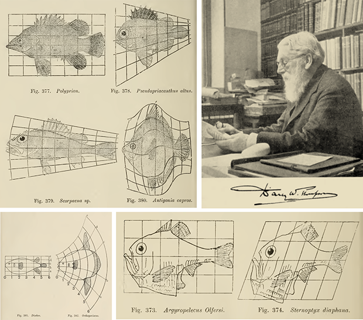

A Brief History and Data Types

Antigoni Kaliontzopoulou, Universitat de Barcelona

30 May, 2026

# Motivation

“The study of form may be descriptive merely, or it may become analytical.  
We begin by describing the shape of an object in simple words of common speech:  
we end by defining it in the precise language of mathematics;  
and the one method tends to follow the other in strict scientific order and historical continuity.”

###### D’Arcy Thompson. (1915). *Trans. Roy. Soc. Edinburgh*

# Morphometrics

- What is morphometrics?
- From Greek: morpho (form) + metrikos (measure)
- The quantification and analysis of morphological objects
- Application of multivariate statistical analysis to the study of variation in plants and animals (Reyment, 1985)
- The study of size and shape
- The quantification of form (Lestrel, 2000)
- **The study of shape variation and its covariation with other variables (Bookstein, 1991)**
- This workshop is concerned with the **quantification of shape as derived from landmark-based methods**, and a proper **evaluation of patterns of shape variation relative to explanatory variables**

# Why Study Shape?

- Historical reasons: natural history studies are largely morphological
- Shape differences delineate obvious biological groups (i.e. alpha-taxonomy)
- Shape covaries with other variables
- Understanding shape and biological form may lead to understanding function

**To properly study shape we require a definition of it**

- The geometric properties of an object that are invariant to changes in translation, rotation, and scale (Bookstein 1991; Dryden and Mardia 1998)
- or… the variation that remains once position, orientation, and scale have been mathematically held constant

# Form and Shape

- For much of the history of biological inquiry, form and shape were synonymous
- Plato & Aristotle: believed that understanding form lead to understanding of function
- Geothe: ‘morphology’ the form of an organism
- Form and shape historically used interchangeably
- Now, more formal definitions of form and shape exist, which provide important distinctions
- Specifically, `Form = size + shape` (current definition)

# Early Uses of Morphology

- For centuries, biologists used morphology to compare organisms
- Species taxonomy, classification, and ecological specialization were all addressed using anatomical properties
- However, morphology was typically described qualitatively, leading to limitations
- Much of the richness of morphological variation not captured
- Limits comparisons to 2 objects (same or different)  
  For > 2 objects, only rank-orderings could be done (A >B >C)
- Rank-ordering implies differences on a continuous scale
- Thus, there was a need to quantitatively compare morphology
- **This moves towards a notion of shape and shape differences**

# Transformation Grids in Art: Durer (1528)

- An intuitive use of shape differences from art!

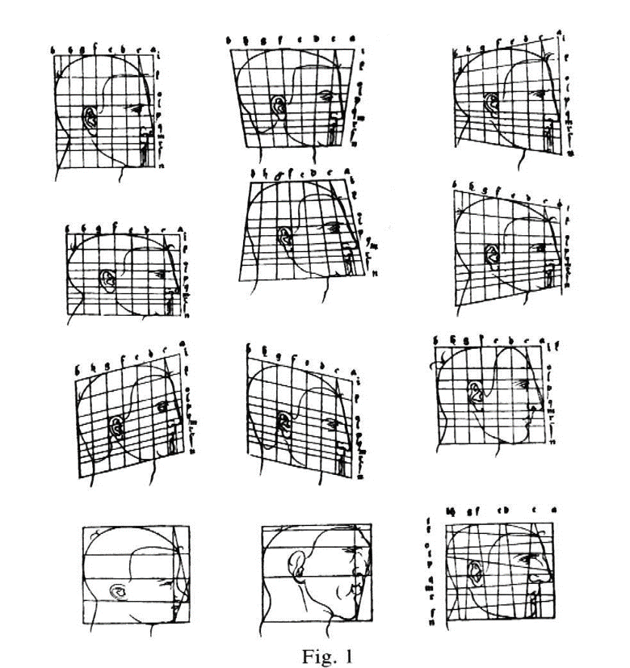

# Transformation Grids in Biology

- Early biological ideas

[figure not shown]

###### Early versions were qualitative. This week we learn the thin-plate spline which enables accurate shape transformations

# The Biometric Tradition

- Use of quantitative data began in the late 1800s: variables were measured (e.g., wing length) and group means compared
- Morphometric advances concurrent with statistical advances
- **LATE 1800s – EARLY 1900s**
- Galton: variation, correlation, regression
- Pearson: more on correlation, $\small\chi^2$
- From this the Biometric tradition was formed, believing that most of biological variation was continuous
- Early 1900s: BIG biological debate: Biometric vs. Mendelian (continuous vs. discontinuous biological variation)

# Development of Statistics

- Statistics developed (as a field) with evolutionary biology
- ANOVA / Variance partitioning (Fisher: for quantitative genetics and more generally)
- Discriminant Function Analysis (DFA/CVA), MANOVA,
- Generalized distance (Fisher, Mahalanobis, Rao)
- Principal Components Analysis (Pearson, Hotelling)
- Multivariate t-test (Hotelling)
- Factor Analysis (Spearman)
- Path Analysis (Wright)
- Most data used were biological
- *THIS* paved the way for morphometrics

# Multivariate Morphometrics

- Multivariate analysis of morphological measurements
- Within- and between-group variation described and compared
- Commonly used methods: principal components, canonical variates, discriminant function (see Blackith and Reyment, 1971)

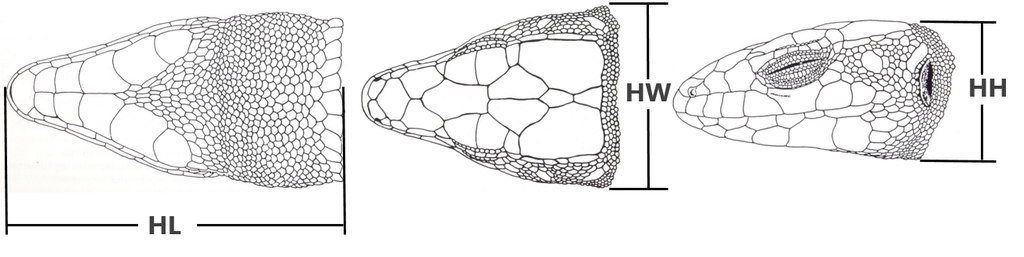

- Related topics:
  - Numerical Taxonomy: Sokal and Sneath, 1963; Sneath and Sokal, 1973
  - Size, shape and allometry (size vs. shape): Jolicoeur, 1963; Burnaby, 1966; Mosimann, 1970

# Geometric Morphometrics

- 1980s-1990s: Theoretical advances and data types caused radical shift in morphometric methods
- **Geometric Morphometric Methods (GMM) emerged**
- Rigorous quantification of shape coupled with sound statistics and graphical visualization
- Emphasis on landmarks due to more formal statistical theory
- Procrustes Paradigm: rigorous quantification of shape from points, curves, and surfaces
- Analysis of shape variation with graphical description of results

[figure not shown]

# Measuring Shapes

- **Morphometrics: the study of shape variation and its covariation**
- How to quantify shape? There are no *natural* units for shape
- Solutions:
  - Use a set of proxy variables to represent shape (morphometric traits)
  - Different approaches use different types of variables and methodologies to obtain them
- **Data should**
  - Register shape in a repeatable manner and archive it for statistical analyses
  - Contain enough information to reconstruct a graphical representation of the structure of interest
  - Be appropriate to address the biological question of interest

# Morphometric Data

- Morphometric data may quantify:
- The location of discrete anatomic features (**points**)
- Distances between anatomic features (**lines**)
- Outlines of a structure (**curves**)
- The surface of a structure (**surfaces**)
- The modern morphometric synthesis permits the combination of ALL these types of data

# Homology in Morphometrics

- Data must quantify shape in a repeatable manner
- Homology: correspondence across specimens
- Evolutionary homology: structures derived from the same tissue of the most recent common ancestor
- Operational homology: correspondence in the position of structures
- In Morphometrics, we may use both, depending on the question to answer
- The important point is to obtain **repeatable** data

# Data Types: Linear Measurements

- Use linear measurements, angles, etc., between anatomic features, or structures (e.g. head width)
- Use some method to eliminate non-shape variation (size)
- Analyze the data using multivariate statistics
- aka ‘traditional’ or “multivariate” morphometrics

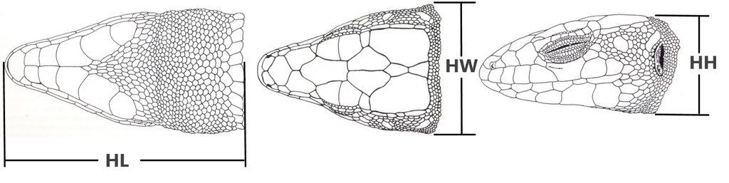

# Linear Measurements: Considerations

**Advantages**

- Allow comparison to previous studies
- The variables used are very intuitive and easy to interpret biologically

**Disadvantages**

- Size is a latent factor and there is no global consensus on how to account for it – different approaches provide different results
- Homology is difficult to evaluate and guarantee
- Usually it is difficult to obtain a graphical representation of variation in shape (because the geometry of the structure is not preserved in the analysis)
- The same values may represent different shapes

# Linear Measures: Same Values Different Shapes

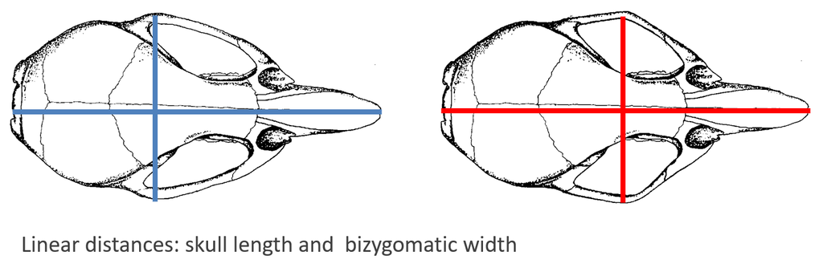

# Linear Measures: Same Values Different Shapes

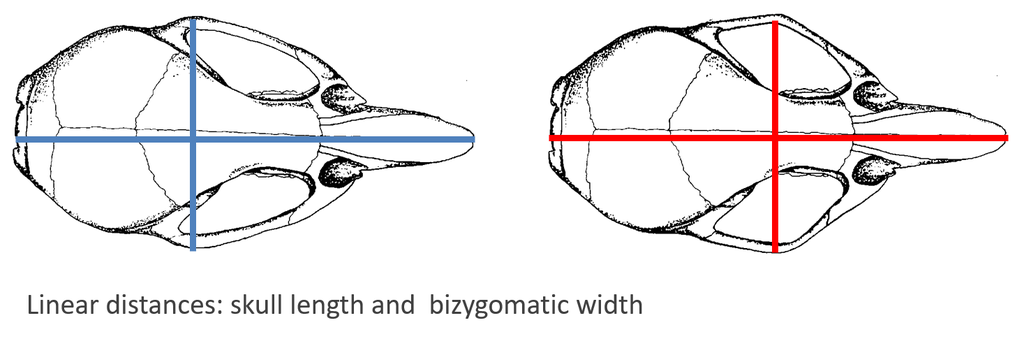

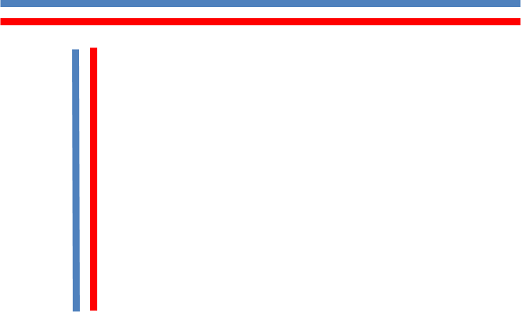

Something is missing! The relative positions of the distances on the structure

# The Truss

- An interconnected network of distance measurements between anatomical points
- An effort to maintain the relative positions between traits
- Can provide a graphical representation
- BUT statistical treatment is problematic

[figure not shown]

# The Morphometric Revolution

- In the 1980s, there is a radical shift in methodology
- Linear measurements do not capture all of the properties required to describe shape
- The truss was an attempt to record relative positions
- This information is inherent in the common endpoints of linear distances
- Change from linear measurements to the locations of points themselves
- Use **landmark coordinates** as the raw data This advance was aided by the simultaneous development of mathematical shape theory

# Data Types: Landmark Coordinates

- Use x, y (or x, y, z) coordinates of anatomic locations to quantify anatomical variation
- Eliminate non-shape variation (size and others, see further on)
- Multivariate data analysis

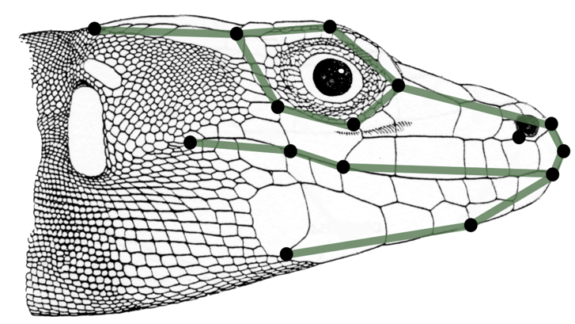

*‘Landmarks are the points at which one’s explanations of biological processes are grounded.’ Bookstein (1990)*

# Types of Landmarks

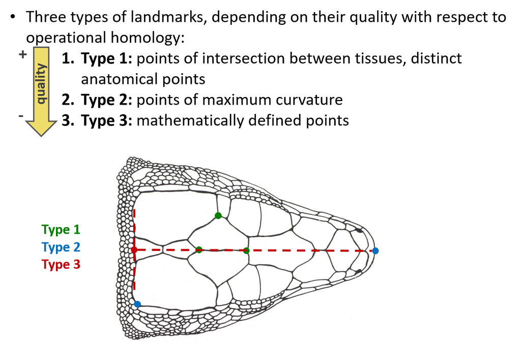

# Landmarks: Considerations

**Advantages**

- Easy to assess homology, so biological interpretation is more robust
- The geometry of the studied structure is maintained in relative landmark locations
- Can obtain a visual representation of shape variation

**Disadvantages**

##### These issues are alleviated through Geometric Morphometric methods and its extensions to other data types, see further on

# Data Types: Curves

- Some structures have few, or no, landmarks
- One may be interested in outlines, or other curves, to quantify shape
- Types of curves
  - **Partial**: different starting and ending points
  - **Complete**: the starting and ending point coincide (closed curves)

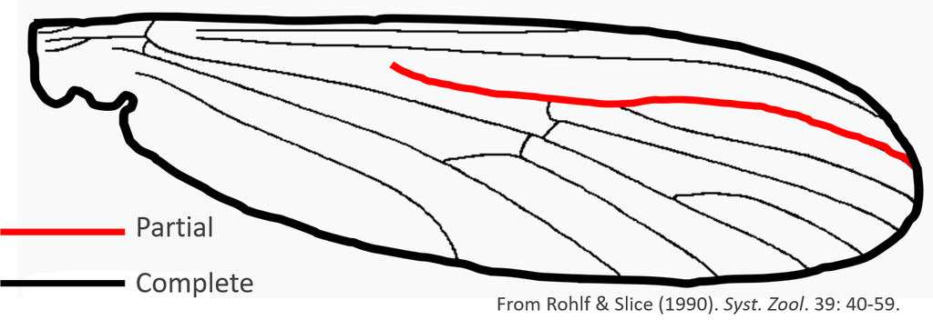

# Curves: Considerations

**Advantages**

- Useful when there are few, or no, landmarks
- They register a full representation of the outline (and therefore we can obtain a graphical representation of shape variation)

**Disadvantages**

- Difficult to assess homology
- Several analytical approaches exist, which provide different variables, and comparison among them is not straightforward (there is no globally accepted way to measure the shape of a curve)
- Most methods do not allow the combination of curves and landmarks
- Some curves may represent different shapes

##### But see next! – The Procrustes paradigm allows the combination of points, curves and surfaces

# Semilandmarks

- They resolve the problems encountered when working with curves
- Can be quantified on curves (2D) or surfaces (3D)
- They are treated as “degenerate” landmarks, the position of which is limited to slide on a curve (or surface) during analysis
- Only variation perpendicular to the curve is relevant

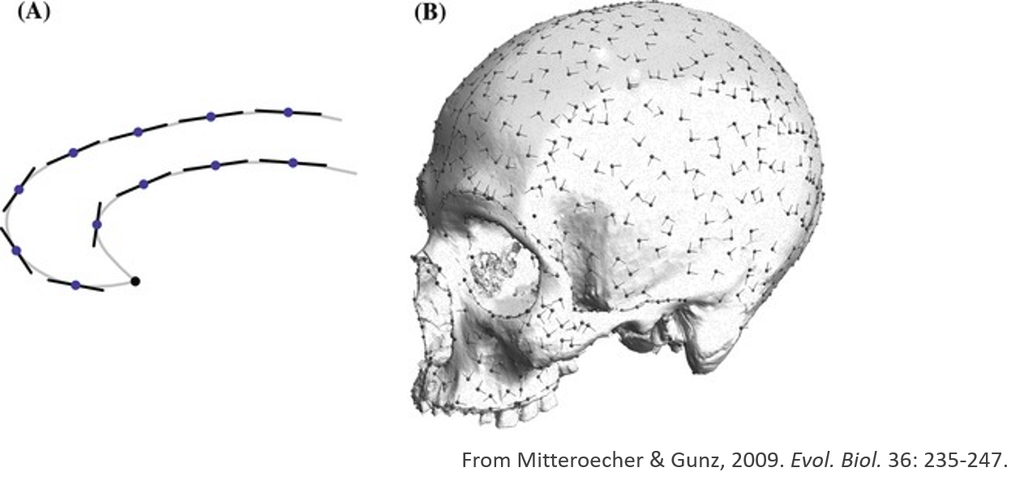

# Semilandmarks: Considerations

**Advantages**

- Good representation of curves, outlines and surfaces
- They allow the examination of curves and surfaces in Procrustes shape space (which has known statistical properties)
- It is possible to combine different morphological features (points, curves, surfaces) in a single analysis of form

# The Procrustes Paradigm

- Combining landmarks and semilandmarks there is a general solution for quantifying biological shape variation
- We obtain quantitative information that represents:
  - Discrete anatomical points
  - Curves (outlines) of structures
  - Surfaces of structures
- We can combine it all in a single analysis!

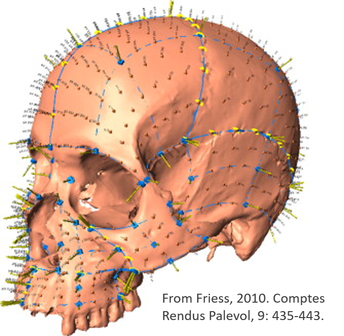

# General Morphometric Protocol

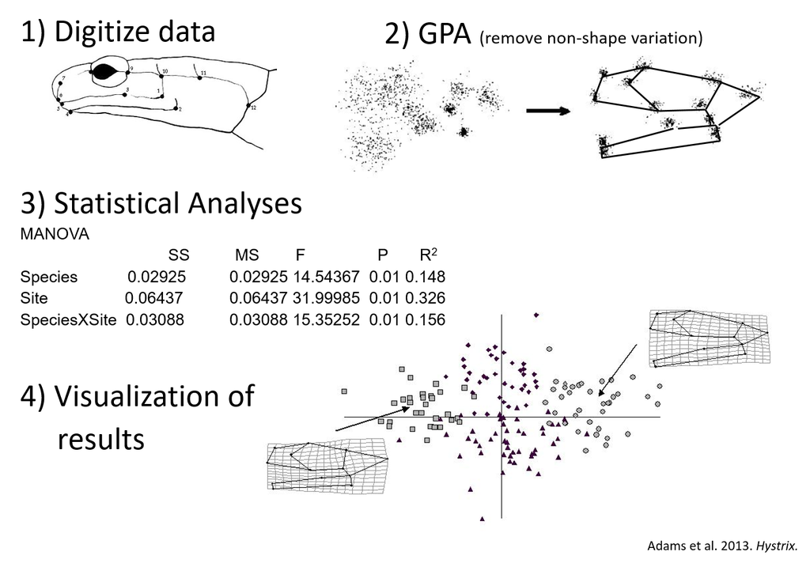

# Special Considerations: Missing Data

- Sometimes landmarks are missing
- Methods to estimate their location exist (discussed later)

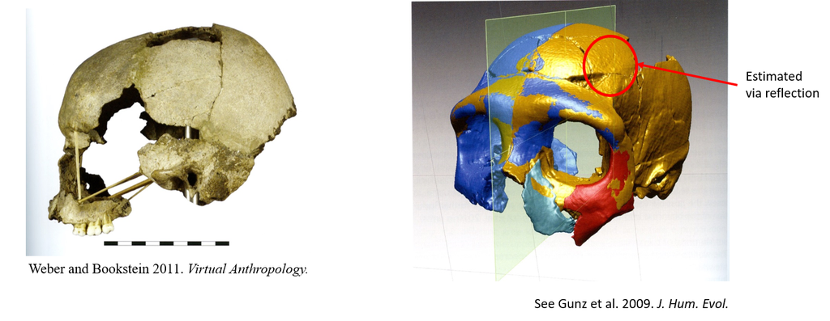

# Special Considerations: Symmetry

- Sometimes objects display symmetry
- GMM procedures adjusted slightly for this (discussed later)

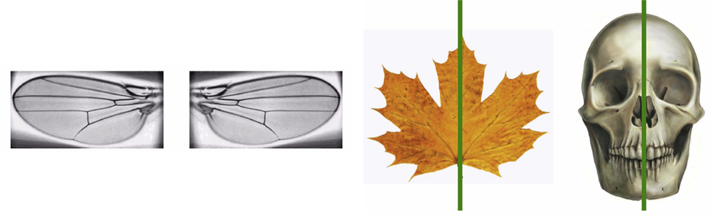